# Part I - Ford GoBike System Data Exploration

## Introduction

This data set includes information about individual trips made in a bike-sharing system covering the greater San Francisco Bay area.

## Preliminary Wrangling

```python
import warnings
warnings.simplefilter("ignore")
```

```python
# import all packages and set plots to be embedded inline
import numpy as np
import pandas as pd
import matplotlib.pyplot as plt
import seaborn as sb

%matplotlib inline
```

Loading the dataset:

```python
bike_data= pd.read_csv('201902-fordgobike-tripdata.csv')
```

```python
bike_data.info()
```

```
<class 'pandas.core.frame.DataFrame'>
RangeIndex: 156090 entries, 0 to 156089
Data columns (total 16 columns):
 #   Column                   Non-Null Count   Dtype
---  ------                   --------------   -----
 0   duration_sec             156090 non-null  int64
 1   start_time               156090 non-null  object
 2   end_time                 156090 non-null  object
 3   start_station_id         155902 non-null  float64
 4   start_station_name       155902 non-null  object
 5   start_station_latitude   156090 non-null  float64
 6   start_station_longitude  156089 non-null  float64
 7   end_station_id           155901 non-null  float64
 8   end_station_name         155901 non-null  object
 9   end_station_latitude     156089 non-null  float64
 10  end_station_longitude    156089 non-null  float64
 11  bike_id                  156089 non-null  float64
 12  user_type                156089 non-null  object
 13  member_birth_year        149098 non-null  float64
 14  member_gender            149098 non-null  object
 15  bike_share_for_all_trip  156089 non-null  object
dtypes: float64(8), int64(1), object(7)
memory usage: 19.1+ MB
```

```python
bike_data['bike_share_for_all_trip'].value_counts()
```

```
No     141344
Yes     14745
Name: bike_share_for_all_trip, dtype: int64
```

```python
bike_data.head(5)
```

|  | duration_sec | start_time | end_time | start_station_id | start_station_name | start_station_latitude | start_station_longitude | end_station_id | end_station_name | end_station_latitude | end_station_longitude | bike_id | user_type | member_birth_year | member_gender | bike_share_for_all_trip |
| --- | --- | --- | --- | --- | --- | --- | --- | --- | --- | --- | --- | --- | --- | --- | --- | --- |
| 0 | 52185 | 2019-02-28 17:32:10.1450 | 2019-03-01 08:01:55.9750 | 21.0 | Montgomery St BART Station (Market St at 2nd St) | 37.789625 | -122.400811 | 13.0 | Commercial St at Montgomery St | 37.794231 | -122.402923 | 4902.0 | Customer | 1984.0 | Male | No |
| 1 | 42521 | 2019-02-28 18:53:21.7890 | 2019-03-01 06:42:03.0560 | 23.0 | The Embarcadero at Steuart St | 37.791464 | -122.391034 | 81.0 | Berry St at 4th St | 37.775880 | -122.393170 | 2535.0 | Customer | NaN | NaN | No |
| 2 | 61854 | 2019-02-28 12:13:13.2180 | 2019-03-01 05:24:08.1460 | 86.0 | Market St at Dolores St | 37.769305 | -122.426826 | 3.0 | Powell St BART Station (Market St at 4th St) | 37.786375 | -122.404904 | 5905.0 | Customer | 1972.0 | Male | No |
| 3 | 36490 | 2019-02-28 17:54:26.0100 | 2019-03-01 04:02:36.8420 | 375.0 | Grove St at Masonic Ave | 37.774836 | -122.446546 | 70.0 | Central Ave at Fell St | 37.773311 | -122.444293 | 6638.0 | Subscriber | 1989.0 | Other | No |
| 4 | 1585 | 2019-02-28 23:54:18.5490 | 2019-03-01 00:20:44.0740 | 7.0 | Frank H Ogawa Plaza | 37.804562 | -122.271738 | 222.0 | 10th Ave at E 15th St | 37.792714 | -122.248780 | 4898.0 | Subscriber | 1974.0 | Male | Yes |

```python
bike_data.describe()
```

|  | duration_sec | start_station_id | start_station_latitude | start_station_longitude | end_station_id | end_station_latitude | end_station_longitude | bike_id | member_birth_year |
| --- | --- | --- | --- | --- | --- | --- | --- | --- | --- |
| count | 156090.000000 | 155902.000000 | 156090.000000 | 156089.000000 | 155901.000000 | 156089.000000 | 156089.000000 | 156089.000000 | 149098.000000 |
| mean | 734.406528 | 138.294531 | 37.771328 | -122.353103 | 136.169364 | 37.771511 | -122.352724 | 4547.248134 | 1984.806087 |
| std | 1831.970777 | 111.891698 | 0.099119 | 0.116690 | 111.697304 | 0.099032 | 0.116306 | 1671.301137 | 10.125336 |
| min | 61.000000 | 3.000000 | 37.317298 | -122.453704 | 3.000000 | 37.317298 | -122.453704 | 11.000000 | 1878.000000 |
| 25% | 327.000000 | 47.000000 | 37.770083 | -122.412408 | 44.000000 | 37.770407 | -122.411726 | 3906.000000 | 1980.000000 |
| 50% | 518.000000 | 102.000000 | 37.780760 | -122.398436 | 100.000000 | 37.780955 | -122.398279 | 4999.000000 | 1987.000000 |
| 75% | 803.000000 | 239.000000 | 37.797280 | -122.287610 | 235.000000 | 37.797280 | -122.289370 | 5573.000000 | 1992.000000 |
| max | 85444.000000 | 398.000000 | 37.880222 | -121.874119 | 398.000000 | 37.880222 | -121.874119 | 6645.000000 | 2001.000000 |

```python
bike_data['user_type'].value_counts()
```

```
Subscriber    138867
Customer       17222
Name: user_type, dtype: int64
```

```python
bike_data['member_gender'].value_counts()
```

```
Male      111111
Female     34839
Other       3148
Name: member_gender, dtype: int64
```

### Quality issue:

start_time and end_time should be of type datetime and not object.

#### Code:

Created a function that takes the dataframe and a column and changes the data type of that column to datetime:

```python
def dt(df,x):
    df[x]=pd.to_datetime(df[x])
```

```python
dt(bike_data,'start_time')
dt(bike_data,'end_time')
```

#### Test:

```python
bike_data.info()
```

```
<class 'pandas.core.frame.DataFrame'>
RangeIndex: 156090 entries, 0 to 156089
Data columns (total 16 columns):
 #   Column                   Non-Null Count   Dtype
---  ------                   --------------   -----
 0   duration_sec             156090 non-null  int64
 1   start_time               156090 non-null  datetime64[ns]
 2   end_time                 156090 non-null  datetime64[ns]
 3   start_station_id         155902 non-null  float64
 4   start_station_name       155902 non-null  object
 5   start_station_latitude   156090 non-null  float64
 6   start_station_longitude  156089 non-null  float64
 7   end_station_id           155901 non-null  float64
 8   end_station_name         155901 non-null  object
 9   end_station_latitude     156089 non-null  float64
 10  end_station_longitude    156089 non-null  float64
 11  bike_id                  156089 non-null  float64
 12  user_type                156089 non-null  object
 13  member_birth_year        149098 non-null  float64
 14  member_gender            149098 non-null  object
 15  bike_share_for_all_trip  156089 non-null  object
dtypes: datetime64[ns](2), float64(8), int64(1), object(5)
memory usage: 19.1+ MB
```

### What is the structure of your dataset?

This dataset contains information about 156090 bike rides with 16 features (duration_sec, start_time, end_time, start_station_id, start_station_name, start_station_latitude, start_station_longitude, end_station_id, end_station_name, end_station_latitude, end_station_longitude, bike_id, user_type, member_birth_year, member_gender).

There are 7 object type variables, and 9 numerical variables.

user_type and member_gender are categorical nominal variables, with:

- user_type: Subscriber (member in the system) - Customer (casual user)
- member_gender: Male - Female - Other

The variable bike_share_for_all_trips indicates whether a member is enrolled in the Bike Share for All program for low-income residents.  
It takes the values of Yes-No .

### What is/are the main feature(s) of interest in your dataset?

Through investigating this dataset, I'm most interested in knowing what affects the trip duration (duration_sec)

### What features in the dataset do you think will help support your investigation into your feature(s) of interest?

The features I'm interested in and that I think might have a relationship with the variable of interest are:

- member gender
- member birth year
- starting stations
- user types
- enrollment in the bike share program

## Univariate Exploration

##### Q: How is the distribution of the duration of bike rides (duration_sec)?

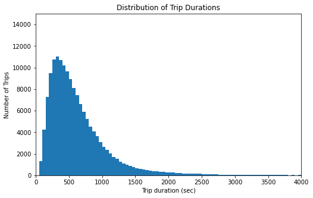

```python
bins = np.arange(0, bike_data['duration_sec'].max()+500, 50)

plt.figure(figsize=[8, 5])
plt.hist(data = bike_data, x = 'duration_sec', bins = bins)
plt.title('Distribution of Trip Durations')
plt.xlabel('Trip duration (sec)')
plt.ylabel('Number of Trips')

#set axis limits
plt.axis([0, 4000, 0, 15000])
plt.show()
```

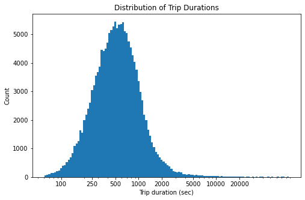

```python
#create bins for the logged values
log_binsize = 0.025
bins = 10 ** np.arange(np.log10(bike_data['duration_sec'].min()),
                       np.log10(bike_data['duration_sec'].max())+log_binsize, log_binsize)

plt.figure(figsize=[8, 5])
plt.hist(data = bike_data, x = 'duration_sec', bins = bins)
plt.xscale('log')

plt.xticks([100,250, 500, 1e3, 2e3, 5e3, 1e4, 2e4], [100,250, 500, 1000, 2000, 5000, 10000, 20000])
plt.title('Distribution of Trip Durations')
plt.xlabel('Trip duration (sec)')
plt.ylabel('Count')
plt.show();
```

When plotted on the log scale, the data points came out normally distributed. There is one peak roughly between 400 and 700 seconds, this shows that most people tend to use bikes for short durations (7 to 12 minutes).

##### Q: I'm also interested in checking the repartition of bike trips between genders:

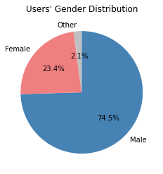

```python
#sort the counts of member_gender to have a neat graph
sorted_counts = bike_data['member_gender'].value_counts()

plt.pie(sorted_counts, labels = sorted_counts.index, colors=('steelblue','lightcoral','silver')
        ,startangle = 90, counterclock = False, autopct = '%1.1f%%')

plt.title("Users' Gender Distribution");
```

Three quarters of the bike system users are males.

##### Q: I'm curious to see the distribution of the user's birth year (i.e their age):

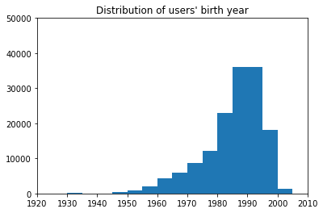

```python
bins=np.arange(1920,2010,5)
plt.hist(data=bike_data, x='member_birth_year', bins=bins)
plt.axis([1920,2010, 0, 50000])
plt.title("Distribution of users' birth year");
```

```python
bike_data['member_birth_year'].describe()
```

```
count    149098.000000
mean       1984.806087
std          10.125336
min        1878.000000
25%        1980.000000
50%        1987.000000
75%        1992.000000
max        2001.000000
Name: member_birth_year, dtype: float64
```

##### Q: I want to check the most frequent starting stations as well as most frequent destinations:

```python
start=bike_data['start_station_name'].value_counts()[0:11]
```

```python
start
```

```
Market St at 10th St                                         3314
San Francisco Caltrain Station 2  (Townsend St at 4th St)    3011
Berry St at 4th St                                           2599
Montgomery St BART Station (Market St at 2nd St)             2505
Powell St BART Station (Market St at 4th St)                 2379
San Francisco Ferry Building (Harry Bridges Plaza)           2311
San Francisco Caltrain (Townsend St at 4th St)               2303
Powell St BART Station (Market St at 5th St)                 1998
Howard St at Beale St                                        1954
Steuart St at Market St                                      1933
The Embarcadero at Sansome St                                1789
Name: start_station_name, dtype: int64
```

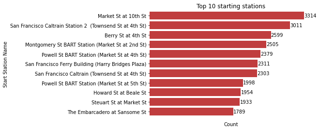

```python
base_color = sb.color_palette()[3]
ax=sb.countplot(data=bike_data, y='start_station_name', color=base_color, order=start.index)

#add count on top of the bar and remove it from the axis
ax.bar_label(ax.containers[0])
ax.set(xticklabels=[])
ax.tick_params(bottom=False)
ax.set_frame_on(False)

plt.xlabel('Count')
plt.ylabel('Start Station Name')
plt.title('Top 10 starting stations');
```

Market St at 10th St and San Francisco Caltarian station 2 clearly are the most frequent starting station with more than 3000 rides each.

```python
end=bike_data['end_station_name'].value_counts()[0:11]
```

```python
end
```

```
San Francisco Caltrain Station 2  (Townsend St at 4th St)    4188
Market St at 10th St                                         3389
Montgomery St BART Station (Market St at 2nd St)             3101
San Francisco Ferry Building (Harry Bridges Plaza)           2913
Powell St BART Station (Market St at 4th St)                 2548
San Francisco Caltrain (Townsend St at 4th St)               2486
Berry St at 4th St                                           2423
The Embarcadero at Sansome St                                2143
Powell St BART Station (Market St at 5th St)                 2020
Steuart St at Market St                                      1969
Howard St at Beale St                                        1753
Name: end_station_name, dtype: int64
```

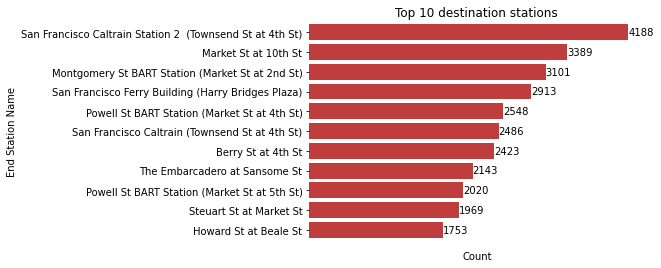

```python
base_color = sb.color_palette()[3]
ax=sb.countplot(data=bike_data, y='end_station_name', color=base_color, order=end.index)

#add count on top of the bar and remove it from the axis
ax.bar_label(ax.containers[0])
ax.set(xticklabels=[])
ax.tick_params(bottom=False)
ax.set_frame_on(False)

plt.xlabel('Count')
plt.ylabel('End Station Name')
plt.title('Top 10 destination stations');
```

San Francisco Caltarian station 2 is clearly the most frequent destination for users with more than 4000 rides followed by Market St at 10th and Montgomery St BART Station.

##### I'm more interested in investigating the starting stations of the system users, rather than the destinations

These stations may reflect where the system users are located.  
I will create a subset of the dataframe with the top 10 starting stations to use it for the analysis of those stations later.

```python
#Creating a subset dataframe containg data with the top 10 starting stations only
top10=bike_data[bike_data['start_station_name'].isin(['Market St at 10th St',
                                                      'San Francisco Caltrain Station 2  (Townsend St at 4th St)',
                                                      'Berry St at 4th St',
                                                      'Montgomery St BART Station (Market St at 2nd St)',
                                                      'Powell St BART Station (Market St at 4th St)',
                                                      'San Francisco Ferry Building (Harry Bridges Plaza)',
                                                      'San Francisco Caltrain (Townsend St at 4th St)',
                                                      'Powell St BART Station (Market St at 5th St) ',
                                                      'Howard St at Beale St' ,
                                                      'Steuart St at Market St',
                                                     'The Embarcadero at Sansome St'])]
```

```python
top10['start_station_name'].value_counts()
```

```
Market St at 10th St                                         3314
San Francisco Caltrain Station 2  (Townsend St at 4th St)    3011
Berry St at 4th St                                           2599
Montgomery St BART Station (Market St at 2nd St)             2505
Powell St BART Station (Market St at 4th St)                 2379
San Francisco Ferry Building (Harry Bridges Plaza)           2311
San Francisco Caltrain (Townsend St at 4th St)               2303
Howard St at Beale St                                        1954
Steuart St at Market St                                      1933
The Embarcadero at Sansome St                                1789
Name: start_station_name, dtype: int64
```

##### Q: I want to check the distribution of user types:

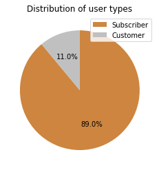

```python
#sort user_type values
sorted_counts = bike_data['user_type'].value_counts()

plt.pie(sorted_counts, colors=('peru','silver')
        ,startangle = 90, counterclock = False, autopct = '%1.1f%%')
plt.title('Distribution of user types')
plt.legend(sorted_counts.index);
```

Most system users are subscribers

##### Q: I want to check the enrollment of system users in the Bike Share for All program for low-income residents:

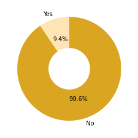

```python
#sort bike_share_for_all_trip values
sorted_counts = bike_data['bike_share_for_all_trip'].value_counts()

plt.pie(sorted_counts, labels = sorted_counts.index, colors=('goldenrod','moccasin')
        ,startangle = 90, counterclock = False, autopct = '%1.1f%%',wedgeprops = {'width' : 0.6});
```

The majority of system subscribers are not enrolled in this system.

### Of the features you investigated, were there any unusual distributions? Did you perform any operations on the data to tidy, adjust, or change the form of the data? If so, why did you do this?

I didn't perform any adjustments to the data investigated

## Bivariate Exploration

```python
bike_data.info()
```

```
<class 'pandas.core.frame.DataFrame'>
RangeIndex: 156090 entries, 0 to 156089
Data columns (total 16 columns):
 #   Column                   Non-Null Count   Dtype
---  ------                   --------------   -----
 0   duration_sec             156090 non-null  int64
 1   start_time               156090 non-null  datetime64[ns]
 2   end_time                 156090 non-null  datetime64[ns]
 3   start_station_id         155902 non-null  float64
 4   start_station_name       155902 non-null  object
 5   start_station_latitude   156090 non-null  float64
 6   start_station_longitude  156089 non-null  float64
 7   end_station_id           155901 non-null  float64
 8   end_station_name         155901 non-null  object
 9   end_station_latitude     156089 non-null  float64
 10  end_station_longitude    156089 non-null  float64
 11  bike_id                  156089 non-null  float64
 12  user_type                156089 non-null  object
 13  member_birth_year        149098 non-null  float64
 14  member_gender            149098 non-null  object
 15  bike_share_for_all_trip  156089 non-null  object
dtypes: datetime64[ns](2), float64(8), int64(1), object(5)
memory usage: 19.1+ MB
```

##### Q: Investigating the relationship between trip duration and user gender:

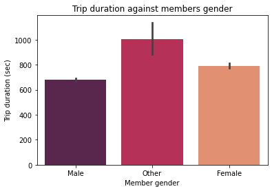

```python
sb.barplot(x=bike_data['member_gender'], y=bike_data['duration_sec'] , palette="rocket")
plt.xlabel('Member gender')
plt.ylabel('Trip duration (sec)')
plt.title('Trip duration against members gender');
```

This graph shows that members with the gender 'other' are the ones with the longest trip duration with an average duration of approximately 1000 seconds.  
But since in the univariate section it was shown that 'other' members are a minority, I'll redo this graph keeping only Male and Female.

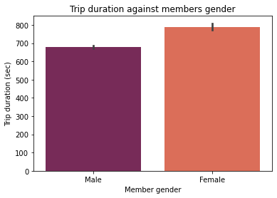

```python
#create new subset with only Male and Female of member_gender values
genders=bike_data[bike_data['member_gender'].isin(['Male','Female'])]

sb.barplot(x=genders['member_gender'], y=genders['duration_sec'] , palette="rocket")
plt.xlabel('Member gender')
plt.ylabel('Trip duration (sec)')
plt.title('Trip duration against members gender');
```

Trip duration is longer for Female members than Males, the difference is not very significant though (around 100 seconds)

##### Q: Now I check for the effect of member's birth year (age) on trip duration:

In the univariate section, I found out that members born before 1975 and after 2000 have unfrequent uses of the system, so I'll only keep the year range (1975,2000)

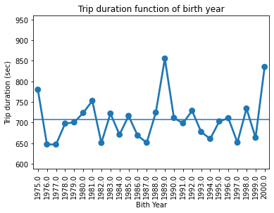

```python
#keep only trips of members born betwwen 1975 and 2000 as this range contains most users of the system
years=bike_data[bike_data['member_birth_year'].isin(np.arange(1975,2001,1))]

sb.pointplot(data = years, x = 'member_birth_year', y = 'duration_sec', errwidth=0)#, linestyles=''
plt.xticks(rotation=90)
plt.xlabel('Bith Year')
plt.ylabel('Trip duration (sec)')
plt.title('Trip duration function of birth year')

# add mean line
plt.axhline(y=np.nanmean(years['duration_sec']));
```

##### Q: I want to see the average trip duration for each starting station:

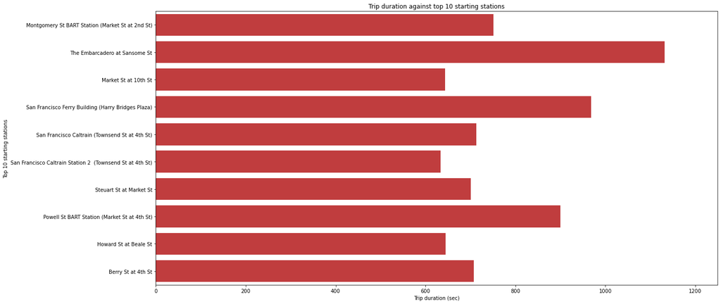

```python
plt.figure(figsize=(20,10))
ax = sb.barplot(data = top10, y = 'start_station_name', x = 'duration_sec', ci=None, color=sb.color_palette()[3])
plt.xlabel('Trip duration (sec)')
plt.ylabel('Top 10 starting stations')
plt.title('Trip duration against top 10 starting stations')

#ser x axis limit
plt.xlim(0,1250);
```

"The Embarcadero at Sansome St" corresponds to the starting station with the highest average trip duration, followed "San Franncisco Feryy Building" and "Powell St BART Station".

##### Q: I want to check how trip duration varies with user type:

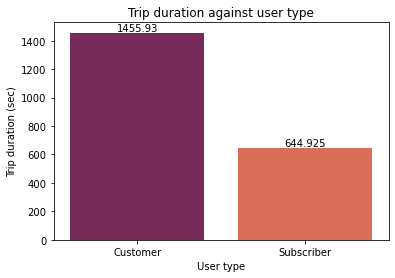

```python
ax=sb.barplot(x=bike_data['user_type'], y=bike_data['duration_sec'] , palette="rocket", ci=None)
plt.xlabel('User type')
plt.ylabel('Trip duration (sec)')
plt.title('Trip duration against user type');

#add count on top of the bar and remove it from the axis
ax.bar_label(ax.containers[0]);
```

Surprisingly, customer (casual users not enrolled in the system) have longer trip durations than subscribers, with averages of 1456 seconds and 645 seconds respectively.

##### Q: Now I want to see if trip duration varies with whether the user is subscribed to the bike-share program for low income residents:

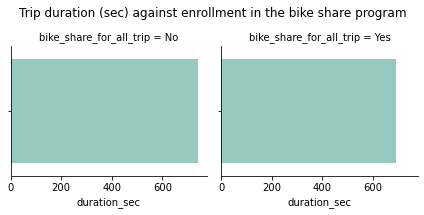

```python
g = sb.FacetGrid(data = bike_data, col = 'bike_share_for_all_trip');

g.map(sb.barplot, "duration_sec",color=sb.color_palette("Set3", 10)[0], ci=None)
#adjust the graph so that the title shows correctly
g.fig.subplots_adjust(top=0.8)

g.fig.suptitle('Trip duration (sec) against enrollment in the bike share program')
plt.show();
```

This figure shows that there is no much difference in trip duration between those who are enrolled in the bike-share for low income program and those who are not: trip duration doesn't depend on the enrollment on this program.

##### Q: I'm curious to know how are the user types distributed between genders:

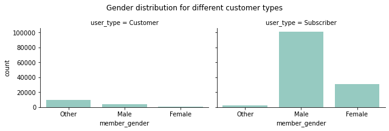

```python
plt.figure(figsize = [10, 10])

g = sb.FacetGrid(data = bike_data, col = 'user_type' , aspect=1.5 ,col_wrap=2, palette='rocket')
g.map(sb.countplot,'member_gender' , color=sb.color_palette("Set3", 10)[0])
#adjust the graph so that the title shows correctly
g.fig.subplots_adjust(top=0.8)

g.fig.suptitle('Gender distribution for different customer types')
plt.show();
```

##### Q: I'm also interested to know if the enrollment in the Bike-share -for-all program is affected by gender:

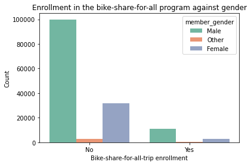

```python
sb.countplot(data = bike_data, x = 'bike_share_for_all_trip', hue = 'member_gender' ,  palette=sb.color_palette("Set2"))
plt.xlabel('Bike-share-for-all-trip enrollment')
plt.ylabel('Count')
plt.title('Enrollment in the bike-share-for-all program against gender');
```

The graph shows a similar gender distribution for whether the member is enrolled in this program or not, it would be safe to say that gender has no effect on enrollent.

##### Q: I want to check if the day hours affect the trip duration:

I start by creating a new column named 'start_hour' containing the starting hour of the trip:

```python
import datetime
from datetime import *
```

```python
#Creating a function that fills a second column with the hours from the first column of type datetime
def hour(nc,oc,df):
    for i in np.arange(0,len(df),1):
        nc[i]=(str(pd.to_datetime(oc[i])).split()[1].split(':')[0])
```

```python
#creating a new column 'start_hour' and initially assigning it the values of 'start_time'
bike_data['start_hour']=bike_data['start_time']

#Filling the new column 'start_hour' with hours using the function defined above
hour(bike_data['start_hour'],bike_data['start_time'],bike_data)
```

```python
bike_data.info()
```

```
<class 'pandas.core.frame.DataFrame'>
RangeIndex: 156090 entries, 0 to 156089
Data columns (total 17 columns):
 #   Column                   Non-Null Count   Dtype
---  ------                   --------------   -----
 0   duration_sec             156090 non-null  int64
 1   start_time               156090 non-null  datetime64[ns]
 2   end_time                 156090 non-null  datetime64[ns]
 3   start_station_id         155902 non-null  float64
 4   start_station_name       155902 non-null  object
 5   start_station_latitude   156090 non-null  float64
 6   start_station_longitude  156089 non-null  float64
 7   end_station_id           155901 non-null  float64
 8   end_station_name         155901 non-null  object
 9   end_station_latitude     156089 non-null  float64
 10  end_station_longitude    156089 non-null  float64
 11  bike_id                  156089 non-null  float64
 12  user_type                156089 non-null  object
 13  member_birth_year        149098 non-null  float64
 14  member_gender            149098 non-null  object
 15  bike_share_for_all_trip  156089 non-null  object
 16  start_hour               156090 non-null  object
dtypes: datetime64[ns](2), float64(8), int64(1), object(6)
memory usage: 20.2+ MB
```

Now I check whether the trip duration is affected by the different day hours when the trip starts:

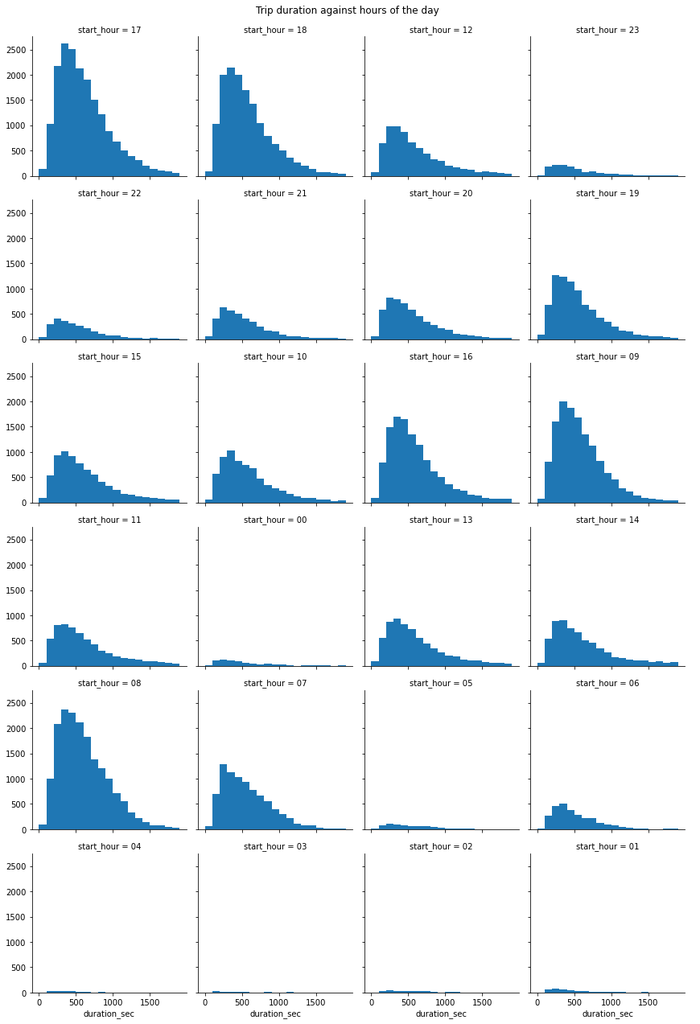

```python
bins=np.arange(0,2000,100)
#Defining the facetgrid
g=sb.FacetGrid(data=bike_data, col='start_hour', col_wrap=4)
#Defining the graph within grids
g.map(plt.hist,'duration_sec', bins=bins)

#Adjusting the plot so that the title shows up correctly
g.fig.subplots_adjust(top=0.95)
g.fig.suptitle('Trip duration against hours of the day')
g.add_legend();
```

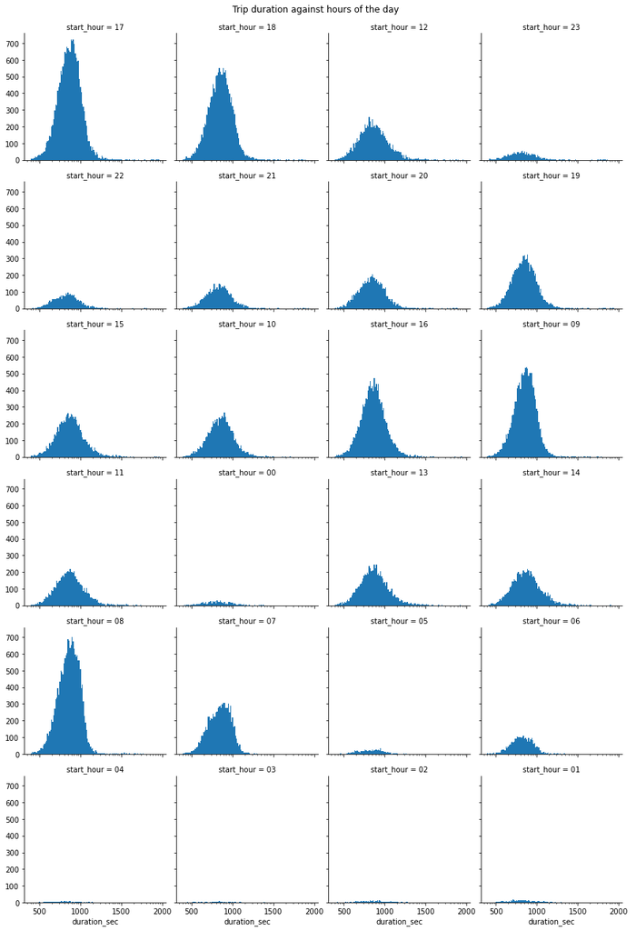

```python
#Creating bins for the logged values
bins = 10 ** np.arange(np.log10(bike_data['duration_sec'].min()),
                       np.log10(bike_data['duration_sec'].max())+log_binsize, 0.025)

g=sb.FacetGrid(data=bike_data, col='start_hour', col_wrap=4)
g.map(plt.hist,'duration_sec', bins=bins)

g.set(xscale = 'log')
x_ticks = [500,1000,1500,2000]
plt.xticks([10**2,10**3,10**4,10**5], x_ticks)

g.fig.subplots_adjust(top=0.95)
g.fig.suptitle('Trip duration against hours of the day')
g.add_legend();
```

It can be seen from the graphs that some hours have more frequent trips like: 16, 17, 18 o'clock and 7, 8, and 9 o'clock.  
This can be understood as these hours correspond to the evening and morning rush hours respectively.  
However, the distribution of trip durations seems to be the same for all hours of the day.

## Multivariate Exploration

#### Q: Does the member gender and birth year (age) affect trip duration?

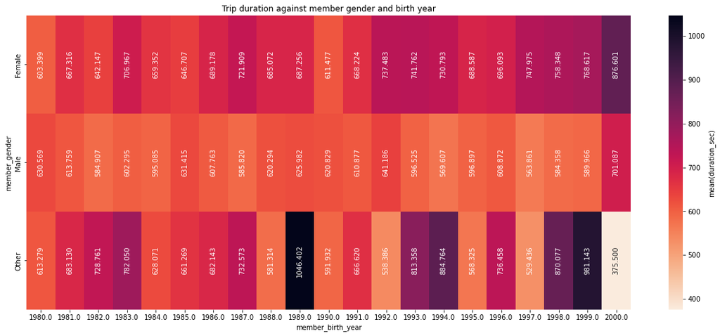

```python
#Creating a sample containg birth year between 1980 and 2000 and trip durations from 0 to 5000 seconds
sample=bike_data[(bike_data["member_birth_year"].isin(np.arange(1980,2001,1))) &
                 (bike_data["duration_sec"].isin(np.arange(0,5001,1)))]

#Creating the mean values that will show inside the heatmap
duration_means = sample.groupby(['member_gender', 'member_birth_year']).mean()['duration_sec']
duration_means = duration_means.reset_index(name = 'duration_avg')
duration_means = duration_means.pivot(index = 'member_gender', columns = 'member_birth_year',
                            values = 'duration_avg')

#Plotting
ax = plt.subplots(figsize=(20, 8))
ax=sb.heatmap(duration_means,  fmt = '.3f', cmap = sb.cm.rocket_r, annot=True,
           cbar_kws = {'label' : 'mean(duration_sec)'}, annot_kws={'rotation': 90})

plt.title('Trip duration against member gender and birth year');
```

- Younger females seem to have longer trip durations.
- Males have slightly higher trip durations than the average for those born between 1988 and 1992, as well as those born on 2000.
- For the gender type "Other", highest trip durations are for members born on 1989, 1999, followed by the years 1194, 1998, and 1993.

##### Q: I want to check how are trip durations assigned to each gender for the top 10 starting stations:

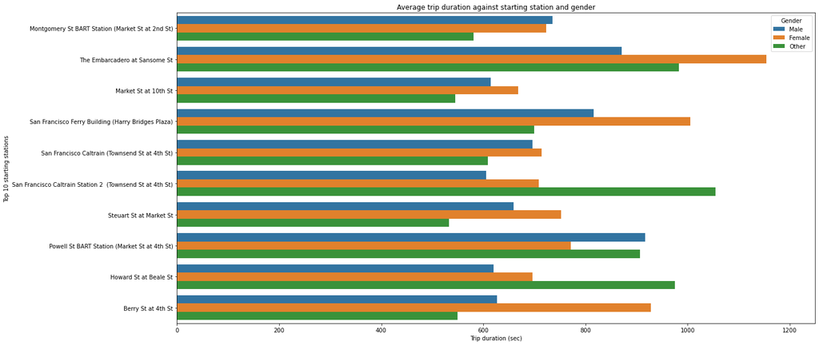

```python
plt.figure(figsize=(20,10))
ax = sb.barplot(data = top10, y = 'start_station_name', x = 'duration_sec', hue = 'member_gender', ci=None)
plt.xlim(0,1250)
plt.title('Average trip duration against starting station and gender')
plt.xlabel('Trip duration (sec)')
plt.ylabel('Top 10 starting stations')

#Naming the legend and locking it in the upper right
ax.legend(loc = 'upper right' ,title = 'Gender');
```

- For "The Embarcadero at Sansome St": Females have the highest average trip duration
- For "San Franncisco Feryy Building": Females have the highest average trip duration
- For "Powell St BART Station": Males and "Other" have almost equal average trip durations, both higher than females.

##### Q: I want to see the relationship between being enrolled in the bike share program, the starting station and the average trip duration:

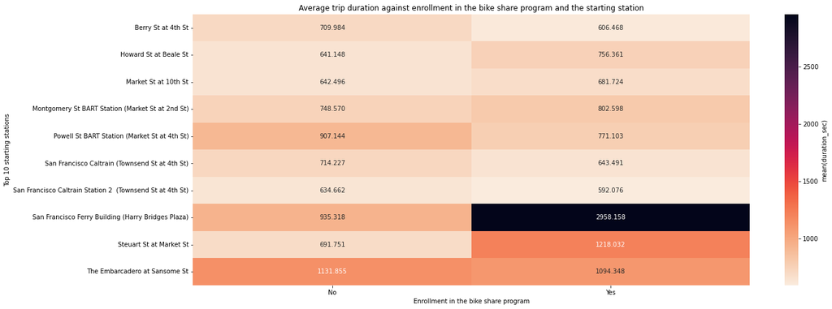

```python
#Creating the mean values that will show inside the heatmap
duration_means = top10.groupby(['start_station_name', 'bike_share_for_all_trip']).mean()['duration_sec']
duration_means = duration_means.reset_index(name = 'duration_avg')
duration_means = duration_means.pivot(index = 'start_station_name', columns = 'bike_share_for_all_trip',
                            values = 'duration_avg')
ax = plt.subplots(figsize=(20, 8))
ax=sb.heatmap(duration_means,  fmt = '.3f', cmap = sb.cm.rocket_r, annot=True,
           cbar_kws = {'label' : 'mean(duration_sec)'})

plt.title('Average trip duration against enrollment in the bike share program and the starting station')
plt.xlabel('Enrollment in the bike share program')
plt.ylabel('Top 10 starting stations');
```

For those enrolled in the bike share program, the highest trip duration corresponds to the starting station of "San Francisco Ferry Building" with a remarkably high average of 2958 seconds, followed by "Steuart St at Market St" and "The Embarcadero at Sansome St".

### Talk about some of the relationships you observed in this part of the investigation. Were there features that strengthened each other in terms of looking at your feature(s) of interest?

- The last graph might give a great insight on where most of those enrolled in the bike share program are located and use the system for longer trip durations.

### Were there any interesting or surprising interactions between features?

- It was interesting to see how trip durations increase for younger females.

## Conclusions

### Steps undertaken:

- I started by investigating the dataset and doing the necessary wrangling and cleaning
- My main feature of interest was the trip duration, and through the univariate, bivariate and multivariate phases, I tried to investigate the relationship between this feature and other variables that thought might have an effect on it, mainly: member gender, member birth year, starting stations, user types, and enrollment in the bike share program.